# 01b_exercises

## Psychoinformatics - Week 1b (Exercises)

by Yi-Ju,CHEN (B06603039@ntu.edu.tw)

## 1 Validating the findings about power poses (8 points)

Do [power poses](https://www.youtube.com/watch?v=Ks-_Mh1QhMc) really work? Let's analyze the [data](http://hpc.psy.ntu.edu.tw/info/01/keller2017.csv) from:

Keller, V. N., Johnson, D. J., & Harder, J. A. (2017). [Meeting your inner super (wo)man: are power poses effective when taught?](http://hpc.psy.ntu.edu.tw/info/01/KellerEtal2017.pdf) Comprehensive Results in Social Psychology, 2(1), 106-122.

where

4 experimental conditions were AC (Aware-Constrictive), AE (Aware-Expansive), UC (Unaware-Constrictive), & UE (Unaware-Expansive)  
and  
3 dependent measures were body expansiveness, performance (in a job interview), & hireability scored by 4 independent raters.

Please construct 3 pandas dataframes df1, and df2, and df3 where  
**df1**, derived from df, has only 13 columns of interest (cond, expansiveness1-4, performance1-4, hire1-4) and no missing values (2 points) ;  
**df2**, derived from df1, has 4 columns that average expansiveness1-4 into "expansiveness", "performance1-4" into "performance", & hire1-4 into "hire" (df1 & df2 should have the same number of rows) (2 points) ;  
**df3**, derived from df2, calculates the means of each dependent variable in each condition (2 points):

[figure not shown]

Finally, run three two-way ANOVAs to see if there is any statistically significant result for each dependent measure (2 point). See [this page](https://www.statology.org/two-way-anova-python/) for an example.

```python
import pandas as pd
df=pd.read_csv("https://ceiba.ntu.edu.tw/course/4671ea/content/keller2017.csv")
df
```

|  | participant | rater_1 | rater_2 | rater_3 | rater_4 | rater_5 | performance_1 | performance_2 | performance_3 | performance_4 | ... | Unnamed: 204 | Unnamed: 205 | Unnamed: 206 | Unnamed: 207 | Unnamed: 208 | Unnamed: 209 | Unnamed: 210 | Unnamed: 211 | Unnamed: 212 | Unnamed: 213 |
| --- | --- | --- | --- | --- | --- | --- | --- | --- | --- | --- | --- | --- | --- | --- | --- | --- | --- | --- | --- | --- | --- |
| 0 | 1 | 1319.0 | 1328.0 | 1231.0 | 1093.0 | NaN | 6.0 | 7.0 | 5.0 | 6.0 | ... | NaN | NaN | NaN | NaN | NaN | NaN | NaN | NaN | NaN | NaN |
| 1 | 2 | 1069.0 | 1225.0 | 1343.0 | NaN | NaN | 6.0 | 5.0 | 5.0 | NaN | ... | NaN | NaN | NaN | NaN | NaN | NaN | NaN | NaN | NaN | NaN |
| 2 | 3 | 1322.0 | 1306.0 | 1031.0 | 1083.0 | NaN | 4.0 | 4.0 | 1.0 | 2.0 | ... | NaN | NaN | NaN | NaN | NaN | NaN | NaN | NaN | NaN | NaN |
| 3 | 4 | 1114.0 | 1178.0 | 1060.0 | 1290.0 | NaN | 6.0 | 4.0 | 4.0 | 5.0 | ... | NaN | NaN | NaN | NaN | NaN | NaN | NaN | NaN | NaN | NaN |
| 4 | 5 | 1372.0 | 1178.0 | 1082.0 | 1341.0 | NaN | 3.0 | 2.0 | 5.0 | 3.0 | ... | NaN | NaN | NaN | NaN | NaN | NaN | NaN | NaN | NaN | NaN |
| 5 | 7 | 1381.0 | 1041.0 | 1087.0 | 1273.0 | NaN | 5.0 | 4.0 | 4.0 | 4.0 | ... | NaN | NaN | NaN | NaN | NaN | NaN | NaN | NaN | NaN | NaN |
| 6 | 8 | 1258.0 | 1036.0 | 1074.0 | 1153.0 | NaN | 2.0 | 2.0 | 2.0 | 2.0 | ... | NaN | NaN | NaN | NaN | NaN | NaN | NaN | NaN | NaN | NaN |
| 7 | 10 | 1139.0 | 1390.0 | 1304.0 | 1273.0 | NaN | 2.0 | 4.0 | 3.0 | 4.0 | ... | NaN | NaN | NaN | NaN | NaN | NaN | NaN | NaN | NaN | NaN |
| 8 | 11 | 1350.0 | 1165.0 | 1330.0 | 1370.0 | NaN | 3.0 | 3.0 | 3.0 | 5.0 | ... | NaN | NaN | NaN | NaN | NaN | NaN | NaN | NaN | NaN | NaN |
| 9 | 12 | 1109.0 | 1159.0 | 1181.0 | NaN | NaN | 1.0 | 4.0 | 3.0 | NaN | ... | NaN | NaN | NaN | NaN | NaN | NaN | NaN | NaN | NaN | NaN |
| 10 | 13 | 1241.0 | 1221.0 | 1282.0 | NaN | NaN | 5.0 | 6.0 | 6.0 | NaN | ... | NaN | NaN | NaN | NaN | NaN | NaN | NaN | NaN | NaN | NaN |
| 11 | 15 | 1340.0 | 1028.0 | 1343.0 | 1032.0 | NaN | 2.0 | 2.0 | 3.0 | 2.0 | ... | NaN | NaN | NaN | NaN | NaN | NaN | NaN | NaN | NaN | NaN |
| 12 | 17 | 1109.0 | 1165.0 | 1256.0 | NaN | NaN | 4.0 | 5.0 | 6.0 | NaN | ... | NaN | NaN | NaN | NaN | NaN | NaN | NaN | NaN | NaN | NaN |
| 13 | 18 | 1131.0 | 1011.0 | 1176.0 | NaN | NaN | 1.0 | 1.0 | 3.0 | NaN | ... | NaN | NaN | NaN | NaN | NaN | NaN | NaN | NaN | NaN | NaN |
| 14 | 19 | NaN | NaN | NaN | NaN | NaN | NaN | NaN | NaN | NaN | ... | NaN | NaN | NaN | NaN | NaN | NaN | NaN | NaN | NaN | NaN |
| 15 | 20 | NaN | NaN | NaN | NaN | NaN | NaN | NaN | NaN | NaN | ... | NaN | NaN | NaN | NaN | NaN | NaN | NaN | NaN | NaN | NaN |
| 16 | 21 | 1007.0 | 1086.0 | 1347.0 | 1374.0 | NaN | 7.0 | 4.0 | 6.0 | 3.0 | ... | NaN | NaN | NaN | NaN | NaN | NaN | NaN | NaN | NaN | NaN |
| 17 | 22 | 1384.0 | 1092.0 | 1326.0 | 1132.0 | NaN | 7.0 | 6.0 | 5.0 | 4.0 | ... | NaN | NaN | NaN | NaN | NaN | NaN | NaN | NaN | NaN | NaN |
| 18 | 23 | 1375.0 | 1225.0 | 1261.0 | 1093.0 | NaN | 3.0 | 5.0 | 1.0 | 1.0 | ... | NaN | NaN | NaN | NaN | NaN | NaN | NaN | NaN | NaN | NaN |
| 19 | 26 | NaN | NaN | NaN | NaN | NaN | NaN | NaN | NaN | NaN | ... | NaN | NaN | NaN | NaN | NaN | NaN | NaN | NaN | NaN | NaN |
| 20 | 28 | 1116.0 | 1092.0 | 1348.0 | 1065.0 | NaN | 4.0 | 2.0 | 5.0 | 5.0 | ... | NaN | NaN | NaN | NaN | NaN | NaN | NaN | NaN | NaN | NaN |
| 21 | 29 | 1398.0 | 1041.0 | 1008.0 | NaN | NaN | 2.0 | 1.0 | 3.0 | NaN | ... | NaN | NaN | NaN | NaN | NaN | NaN | NaN | NaN | NaN | NaN |
| 22 | 30 | 1241.0 | 1005.0 | 1351.0 | 1320.0 | NaN | 2.0 | 5.0 | 1.0 | 5.0 | ... | NaN | NaN | NaN | NaN | NaN | NaN | NaN | NaN | NaN | NaN |
| 23 | 31 | 1299.0 | 1246.0 | 1094.0 | 1018.0 | NaN | 1.0 | 7.0 | 5.0 | 3.0 | ... | NaN | NaN | NaN | NaN | NaN | NaN | NaN | NaN | NaN | NaN |
| 24 | 32 | 1037.0 | 1229.0 | 1174.0 | NaN | NaN | 7.0 | 6.0 | 6.0 | NaN | ... | NaN | NaN | NaN | NaN | NaN | NaN | NaN | NaN | NaN | NaN |
| 25 | 33 | 1292.0 | 1128.0 | 1147.0 | NaN | NaN | 4.0 | 3.0 | 5.0 | NaN | ... | NaN | NaN | NaN | NaN | NaN | NaN | NaN | NaN | NaN | NaN |
| 26 | 34 | 1116.0 | 1025.0 | 1329.0 | NaN | NaN | 5.0 | 2.0 | 4.0 | NaN | ... | NaN | NaN | NaN | NaN | NaN | NaN | NaN | NaN | NaN | NaN |
| 27 | 36 | 1152.0 | 1185.0 | 1298.0 | 1026.0 | NaN | 2.0 | 5.0 | 5.0 | 3.0 | ... | NaN | NaN | NaN | NaN | NaN | NaN | NaN | NaN | NaN | NaN |
| 28 | 37 | 1056.0 | 1151.0 | 1170.0 | 1014.0 | NaN | 3.0 | 3.0 | 2.0 | 5.0 | ... | NaN | NaN | NaN | NaN | NaN | NaN | NaN | NaN | NaN | NaN |
| 29 | 38 | 1340.0 | 1036.0 | 1129.0 | 1359.0 | NaN | 5.0 | 5.0 | 2.0 | 2.0 | ... | NaN | NaN | NaN | NaN | NaN | NaN | NaN | NaN | NaN | NaN |
| ... | ... | ... | ... | ... | ... | ... | ... | ... | ... | ... | ... | ... | ... | ... | ... | ... | ... | ... | ... | ... | ... |
| 262 | 620 | 1049.0 | 1090.0 | 1323.0 | 1018.0 | NaN | 1.0 | 1.0 | 1.0 | 1.0 | ... | NaN | NaN | NaN | NaN | NaN | NaN | NaN | NaN | NaN | NaN |
| 263 | 623 | 1398.0 | 1193.0 | 1298.0 | NaN | NaN | 4.0 | 6.0 | 4.0 | NaN | ... | NaN | NaN | NaN | NaN | NaN | NaN | NaN | NaN | NaN | NaN |
| 264 | 624 | NaN | NaN | NaN | NaN | NaN | NaN | NaN | NaN | NaN | ... | NaN | NaN | NaN | NaN | NaN | NaN | NaN | NaN | NaN | NaN |
| 265 | 625 | 1051.0 | 1000.0 | 1184.0 | 1032.0 | NaN | 4.0 | 5.0 | 7.0 | 4.0 | ... | NaN | NaN | NaN | NaN | NaN | NaN | NaN | NaN | NaN | NaN |
| 266 | 627 | NaN | NaN | NaN | NaN | NaN | NaN | NaN | NaN | NaN | ... | NaN | NaN | NaN | NaN | NaN | NaN | NaN | NaN | NaN | NaN |
| 267 | 630 | 1322.0 | 1090.0 | 1097.0 | 1024.0 | NaN | 3.0 | 1.0 | 1.0 | 4.0 | ... | NaN | NaN | NaN | NaN | NaN | NaN | NaN | NaN | NaN | NaN |
| 268 | 642 | 1085.0 | 1027.0 | 1212.0 | 1392.0 | NaN | 6.0 | 4.0 | 6.0 | 6.0 | ... | NaN | NaN | NaN | NaN | NaN | NaN | NaN | NaN | NaN | NaN |
| 269 | 645 | 1134.0 | 1382.0 | 1232.0 | 1104.0 | NaN | 5.0 | 5.0 | 7.0 | 6.0 | ... | NaN | NaN | NaN | NaN | NaN | NaN | NaN | NaN | NaN | NaN |
| 270 | 646 | 1279.0 | 1000.0 | 1307.0 | 1104.0 | NaN | 5.0 | 3.0 | 3.0 | 5.0 | ... | NaN | NaN | NaN | NaN | NaN | NaN | NaN | NaN | NaN | NaN |
| 271 | 648 | 1350.0 | 1281.0 | 1231.0 | 1370.0 | NaN | 2.0 | 4.0 | 3.0 | 2.0 | ... | NaN | NaN | NaN | NaN | NaN | NaN | NaN | NaN | NaN | NaN |
| 272 | 650 | NaN | NaN | NaN | NaN | NaN | NaN | NaN | NaN | NaN | ... | NaN | NaN | NaN | NaN | NaN | NaN | NaN | NaN | NaN | NaN |
| 273 | 654 | 1081.0 | 1253.0 | 1031.0 | 1061.0 | NaN | 1.0 | 3.0 | 1.0 | 1.0 | ... | NaN | NaN | NaN | NaN | NaN | NaN | NaN | NaN | NaN | NaN |
| 274 | 657 | 1134.0 | 1369.0 | 1276.0 | NaN | NaN | 1.0 | 2.0 | 3.0 | NaN | ... | NaN | NaN | NaN | NaN | NaN | NaN | NaN | NaN | NaN | NaN |
| 275 | 658 | 1280.0 | 1101.0 | 1181.0 | 1300.0 | NaN | 2.0 | 1.0 | 4.0 | 5.0 | ... | NaN | NaN | NaN | NaN | NaN | NaN | NaN | NaN | NaN | NaN |
| 276 | 660 | 1152.0 | 1197.0 | 1333.0 | NaN | NaN | 2.0 | 2.0 | 1.0 | NaN | ... | NaN | NaN | NaN | NaN | NaN | NaN | NaN | NaN | NaN | NaN |
| 277 | 670 | 1105.0 | 1025.0 | 1224.0 | 1145.0 | NaN | 6.0 | 7.0 | 5.0 | 7.0 | ... | NaN | NaN | NaN | NaN | NaN | NaN | NaN | NaN | NaN | NaN |
| 278 | 671 | 1381.0 | 1197.0 | 1077.0 | 1205.0 | NaN | 3.0 | 2.0 | 3.0 | 1.0 | ... | NaN | NaN | NaN | NaN | NaN | NaN | NaN | NaN | NaN | NaN |
| 279 | 672 | 1047.0 | 1011.0 | 1146.0 | NaN | NaN | 6.0 | 5.0 | 4.0 | NaN | ... | NaN | NaN | NaN | NaN | NaN | NaN | NaN | NaN | NaN | NaN |
| 280 | 673 | 1319.0 | 1328.0 | 1231.0 | NaN | NaN | 1.0 | 5.0 | 3.0 | NaN | ... | NaN | NaN | NaN | NaN | NaN | NaN | NaN | NaN | NaN | NaN |
| 281 | 674 | 1183.0 | 1070.0 | 1323.0 | 1126.0 | NaN | 2.0 | 2.0 | 6.0 | 5.0 | ... | NaN | NaN | NaN | NaN | NaN | NaN | NaN | NaN | NaN | NaN |
| 282 | 675 | 1051.0 | 1369.0 | 1348.0 | 1009.0 | NaN | 6.0 | 6.0 | 6.0 | 2.0 | ... | NaN | NaN | NaN | NaN | NaN | NaN | NaN | NaN | NaN | NaN |
| 283 | 687 | 1045.0 | 1041.0 | 1206.0 | 1203.0 | NaN | 5.0 | 4.0 | 5.0 | 2.0 | ... | NaN | NaN | NaN | NaN | NaN | NaN | NaN | NaN | NaN | NaN |
| 284 | 689 | 1118.0 | 1090.0 | 1163.0 | 1032.0 | NaN | 5.0 | 5.0 | 5.0 | 6.0 | ... | NaN | NaN | NaN | NaN | NaN | NaN | NaN | NaN | NaN | NaN |
| 285 | 690 | 1037.0 | 1108.0 | 1347.0 | 1132.0 | NaN | 6.0 | 6.0 | 4.0 | 4.0 | ... | NaN | NaN | NaN | NaN | NaN | NaN | NaN | NaN | NaN | NaN |
| 286 | 692 | 1049.0 | 1005.0 | 1184.0 | 1145.0 | NaN | 1.0 | 4.0 | 1.0 | 3.0 | ... | NaN | NaN | NaN | NaN | NaN | NaN | NaN | NaN | NaN | NaN |
| 287 | 693 | 1045.0 | 1303.0 | 1097.0 | 1349.0 | NaN | 4.0 | 4.0 | 3.0 | 4.0 | ... | NaN | NaN | NaN | NaN | NaN | NaN | NaN | NaN | NaN | NaN |
| 288 | 694 | NaN | NaN | NaN | NaN | NaN | NaN | NaN | NaN | NaN | ... | NaN | NaN | NaN | NaN | NaN | NaN | NaN | NaN | NaN | NaN |
| 289 | 695 | 1220.0 | 1041.0 | 1333.0 | 1026.0 | NaN | 5.0 | 5.0 | 3.0 | 5.0 | ... | NaN | NaN | NaN | NaN | NaN | NaN | NaN | NaN | NaN | NaN |
| 290 | 697 | 1130.0 | 1289.0 | 1298.0 | 1093.0 | NaN | 2.0 | 4.0 | 2.0 | 3.0 | ... | NaN | NaN | NaN | NaN | NaN | NaN | NaN | NaN | NaN | NaN |
| 291 | 698 | 1007.0 | 1000.0 | 1304.0 | 1260.0 | NaN | 1.0 | 2.0 | 1.0 | 2.0 | ... | NaN | NaN | NaN | NaN | NaN | NaN | NaN | NaN | NaN | NaN |

292 rows × 214 columns

```python
# what's the different between this synax and the filter?
# df_1=df[['cond','expansiveness_1','expansiveness_2','expansiveness_3','expansiveness_4'
#         ,'performance_1','performance_2','performance_3','performance_4'
#         ,'hire_1','hire_2','hire_3','hire_4']]
df1=df.filter(['cond','expansiveness_1','expansiveness_2','expansiveness_3','expansiveness_4'
        ,'performance_1','performance_2','performance_3','performance_4'
        ,'hire_1','hire_2','hire_3','hire_4']).dropna()
#combine [filter], [dropna], choosing the interest columns without missing value
df1
```

|  | cond | expansiveness_1 | expansiveness_2 | expansiveness_3 | expansiveness_4 | performance_1 | performance_2 | performance_3 | performance_4 | hire_1 | hire_2 | hire_3 | hire_4 |
| --- | --- | --- | --- | --- | --- | --- | --- | --- | --- | --- | --- | --- | --- |
| 0 | UC | 4.0 | 7.0 | 5.0 | 6.0 | 6.0 | 7.0 | 5.0 | 6.0 | 1.0 | 1.0 | 1.0 | 1.0 |
| 2 | UE | 4.0 | 2.0 | 2.0 | 5.0 | 4.0 | 4.0 | 1.0 | 2.0 | 2.0 | 1.0 | 3.0 | 3.0 |
| 3 | UE | 3.0 | 4.0 | 3.0 | 2.0 | 6.0 | 4.0 | 4.0 | 5.0 | 1.0 | 2.0 | 2.0 | 2.0 |
| 4 | AC | 2.0 | 5.0 | 4.0 | 4.0 | 3.0 | 2.0 | 5.0 | 3.0 | 2.0 | 3.0 | 2.0 | 2.0 |
| 5 | UC | 2.0 | 1.0 | 4.0 | 3.0 | 5.0 | 4.0 | 4.0 | 4.0 | 2.0 | 2.0 | 2.0 | 2.0 |
| 6 | UE | 4.0 | 7.0 | 3.0 | 3.0 | 2.0 | 2.0 | 2.0 | 2.0 | 2.0 | 2.0 | 2.0 | 3.0 |
| 7 | AE | 1.0 | 5.0 | 5.0 | 3.0 | 2.0 | 4.0 | 3.0 | 4.0 | 3.0 | 1.0 | 2.0 | 2.0 |
| 8 | UC | 3.0 | 2.0 | 5.0 | 1.0 | 3.0 | 3.0 | 3.0 | 5.0 | 2.0 | 2.0 | 2.0 | 2.0 |
| 11 | AC | 1.0 | 3.0 | 3.0 | 2.0 | 2.0 | 2.0 | 3.0 | 2.0 | 3.0 | 3.0 | 3.0 | 3.0 |
| 16 | AC | 5.0 | 4.0 | 5.0 | 6.0 | 7.0 | 4.0 | 6.0 | 3.0 | 1.0 | 1.0 | 1.0 | 2.0 |
| 17 | UE | 5.0 | 6.0 | 5.0 | 5.0 | 7.0 | 6.0 | 5.0 | 4.0 | 2.0 | 1.0 | 1.0 | 2.0 |
| 18 | AE | 3.0 | 4.0 | 1.0 | 2.0 | 3.0 | 5.0 | 1.0 | 1.0 | 2.0 | 2.0 | 3.0 | 3.0 |
| 20 | AC | 3.0 | 2.0 | 6.0 | 1.0 | 4.0 | 2.0 | 5.0 | 5.0 | 2.0 | 3.0 | 1.0 | 2.0 |
| 22 | AE | 5.0 | 2.0 | 1.0 | 6.0 | 2.0 | 5.0 | 1.0 | 5.0 | 3.0 | 2.0 | 3.0 | 1.0 |
| 23 | UC | 1.0 | 7.0 | 3.0 | 2.0 | 1.0 | 7.0 | 5.0 | 3.0 | 3.0 | 1.0 | 1.0 | 2.0 |
| 27 | AE | 4.0 | 3.0 | 5.0 | 3.0 | 2.0 | 5.0 | 5.0 | 3.0 | 1.0 | 1.0 | 1.0 | 2.0 |
| 28 | UE | 5.0 | 5.0 | 2.0 | 2.0 | 3.0 | 3.0 | 2.0 | 5.0 | 2.0 | 2.0 | 3.0 | 1.0 |
| 29 | AC | 1.0 | 2.0 | 1.0 | 2.0 | 5.0 | 5.0 | 2.0 | 2.0 | 1.0 | 2.0 | 3.0 | 3.0 |
| 30 | AE | 2.0 | 3.0 | 1.0 | 4.0 | 2.0 | 2.0 | 2.0 | 2.0 | 3.0 | 2.0 | 2.0 | 3.0 |
| 31 | UE | 1.0 | 3.0 | 1.0 | 2.0 | 1.0 | 4.0 | 1.0 | 2.0 | 3.0 | 2.0 | 3.0 | 3.0 |
| 32 | AE | 2.0 | 5.0 | 3.0 | 2.0 | 4.0 | 6.0 | 2.0 | 2.0 | 1.0 | 1.0 | 3.0 | 3.0 |
| 34 | UC | 3.0 | 3.0 | 2.0 | 4.0 | 3.0 | 3.0 | 3.0 | 5.0 | 3.0 | 3.0 | 2.0 | 2.0 |
| 35 | AE | 5.0 | 6.0 | 5.0 | 6.0 | 6.0 | 5.0 | 6.0 | 4.0 | 1.0 | 2.0 | 1.0 | 2.0 |
| 36 | UC | 4.0 | 3.0 | 2.0 | 2.0 | 3.0 | 2.0 | 2.0 | 1.0 | 2.0 | 2.0 | 3.0 | 3.0 |
| 37 | AC | 4.0 | 6.0 | 4.0 | 3.0 | 5.0 | 6.0 | 3.0 | 4.0 | 1.0 | 1.0 | 2.0 | 1.0 |
| 39 | AC | 4.0 | 5.0 | 2.0 | 6.0 | 4.0 | 4.0 | 6.0 | 6.0 | 1.0 | 2.0 | 1.0 | 1.0 |
| 40 | AE | 4.0 | 4.0 | 4.0 | 3.0 | 6.0 | 5.0 | 4.0 | 2.0 | 1.0 | 2.0 | 2.0 | 2.0 |
| 41 | UE | 3.0 | 1.0 | 4.0 | 2.0 | 4.0 | 5.0 | 5.0 | 2.0 | 2.0 | 1.0 | 1.0 | 3.0 |
| 42 | UE | 3.0 | 2.0 | 2.0 | 4.0 | 2.0 | 1.0 | 2.0 | 1.0 | 2.0 | 3.0 | 2.0 | 3.0 |
| 43 | UC | 2.0 | 7.0 | 2.0 | 2.0 | 5.0 | 7.0 | 2.0 | 2.0 | 2.0 | 1.0 | 3.0 | 2.0 |
| ... | ... | ... | ... | ... | ... | ... | ... | ... | ... | ... | ... | ... | ... |
| 248 | AC | 2.0 | 4.0 | 3.0 | 6.0 | 2.0 | 5.0 | 5.0 | 6.0 | 2.0 | 1.0 | 1.0 | 1.0 |
| 249 | AC | 6.0 | 5.0 | 6.0 | 4.0 | 6.0 | 6.0 | 6.0 | 6.0 | 1.0 | 1.0 | 1.0 | 1.0 |
| 250 | AC | 5.0 | 1.0 | 1.0 | 2.0 | 4.0 | 3.0 | 4.0 | 3.0 | 1.0 | 2.0 | 1.0 | 2.0 |
| 251 | AE | 5.0 | 2.0 | 2.0 | 2.0 | 2.0 | 1.0 | 3.0 | 3.0 | 3.0 | 3.0 | 2.0 | 2.0 |
| 252 | UE | 4.0 | 2.0 | 2.0 | 3.0 | 3.0 | 1.0 | 1.0 | 4.0 | 2.0 | 2.0 | 3.0 | 1.0 |
| 254 | UC | 3.0 | 3.0 | 4.0 | 4.0 | 5.0 | 3.0 | 4.0 | 4.0 | 1.0 | 2.0 | 2.0 | 1.0 |
| 255 | AE | 3.0 | 4.0 | 4.0 | 4.0 | 3.0 | 4.0 | 5.0 | 6.0 | 2.0 | 2.0 | 2.0 | 1.0 |
| 257 | AC | 2.0 | 4.0 | 6.0 | 6.0 | 2.0 | 1.0 | 6.0 | 6.0 | 3.0 | 3.0 | 2.0 | 1.0 |
| 260 | AE | 2.0 | 3.0 | 2.0 | 5.0 | 2.0 | 1.0 | 1.0 | 2.0 | 3.0 | 3.0 | 3.0 | 1.0 |
| 262 | UC | 1.0 | 2.0 | 2.0 | 1.0 | 1.0 | 1.0 | 1.0 | 1.0 | 3.0 | 3.0 | 2.0 | 3.0 |
| 265 | UC | 5.0 | 3.0 | 6.0 | 3.0 | 4.0 | 5.0 | 7.0 | 4.0 | 2.0 | 2.0 | 1.0 | 2.0 |
| 267 | AE | 3.0 | 7.0 | 7.0 | 6.0 | 3.0 | 1.0 | 1.0 | 4.0 | 3.0 | 3.0 | 3.0 | 2.0 |
| 268 | AC | 5.0 | 4.0 | 5.0 | 6.0 | 6.0 | 4.0 | 6.0 | 6.0 | 1.0 | 2.0 | 1.0 | 1.0 |
| 269 | UE | 6.0 | 3.0 | 5.0 | 6.0 | 5.0 | 5.0 | 7.0 | 6.0 | 1.0 | 2.0 | 1.0 | 1.0 |
| 270 | UE | 3.0 | 4.0 | 2.0 | 5.0 | 5.0 | 3.0 | 3.0 | 5.0 | 1.0 | 2.0 | 2.0 | 1.0 |
| 271 | UE | 4.0 | 5.0 | 4.0 | 7.0 | 2.0 | 4.0 | 3.0 | 2.0 | 3.0 | 1.0 | 2.0 | 2.0 |
| 273 | UE | 1.0 | 1.0 | 1.0 | 1.0 | 1.0 | 3.0 | 1.0 | 1.0 | 2.0 | 3.0 | 3.0 | 3.0 |
| 275 | UE | 2.0 | 1.0 | 5.0 | 5.0 | 2.0 | 1.0 | 4.0 | 5.0 | 3.0 | 3.0 | 3.0 | 2.0 |
| 277 | UE | 5.0 | 4.0 | 5.0 | 6.0 | 6.0 | 7.0 | 5.0 | 7.0 | 1.0 | 1.0 | 1.0 | 1.0 |
| 278 | UC | 3.0 | 6.0 | 2.0 | 2.0 | 3.0 | 2.0 | 3.0 | 1.0 | 2.0 | 3.0 | 1.0 | 3.0 |
| 281 | UC | 4.0 | 1.0 | 2.0 | 4.0 | 2.0 | 2.0 | 6.0 | 5.0 | 2.0 | 3.0 | 1.0 | 1.0 |
| 282 | AE | 5.0 | 2.0 | 6.0 | 2.0 | 6.0 | 6.0 | 6.0 | 2.0 | 1.0 | 1.0 | 1.0 | 3.0 |
| 283 | AE | 6.0 | 2.0 | 4.0 | 2.0 | 5.0 | 4.0 | 5.0 | 2.0 | 1.0 | 2.0 | 2.0 | 3.0 |
| 284 | AE | 5.0 | 4.0 | 5.0 | 6.0 | 5.0 | 5.0 | 5.0 | 6.0 | 3.0 | 1.0 | 1.0 | 1.0 |
| 285 | UE | 4.0 | 5.0 | 7.0 | 3.0 | 6.0 | 6.0 | 4.0 | 4.0 | 1.0 | 1.0 | 3.0 | 2.0 |
| 286 | AE | 2.0 | 4.0 | 2.0 | 4.0 | 1.0 | 4.0 | 1.0 | 3.0 | 3.0 | 2.0 | 3.0 | 2.0 |
| 287 | UC | 4.0 | 3.0 | 2.0 | 2.0 | 4.0 | 4.0 | 3.0 | 4.0 | 2.0 | 1.0 | 2.0 | 2.0 |
| 289 | UC | 6.0 | 6.0 | 4.0 | 5.0 | 5.0 | 5.0 | 3.0 | 5.0 | 2.0 | 1.0 | 2.0 | 2.0 |
| 290 | UE | 2.0 | 5.0 | 2.0 | 2.0 | 2.0 | 4.0 | 2.0 | 3.0 | 3.0 | 2.0 | 2.0 | 3.0 |
| 291 | AE | 1.0 | 5.0 | 3.0 | 3.0 | 1.0 | 2.0 | 1.0 | 2.0 | 3.0 | 3.0 | 3.0 | 2.0 |

194 rows × 13 columns

```python
df2=df1.filter(['cond'])
df2['expansiveness']=df1.iloc[:,[1,2,3,4]].mean(axis='columns')
df2['performance']=df1.iloc[:,[5,6,7,8]].mean(axis='columns')
df2['hire']=df1.iloc[:,[9,10,11,12]].mean(axis='columns')
# using [iloc] selecting columns, and calculting mean under the contidion of 'columns'
df2
```

|  | cond | expansiveness | performance | hire |
| --- | --- | --- | --- | --- |
| 0 | UC | 5.50 | 6.00 | 1.00 |
| 2 | UE | 3.25 | 2.75 | 2.25 |
| 3 | UE | 3.00 | 4.75 | 1.75 |
| 4 | AC | 3.75 | 3.25 | 2.25 |
| 5 | UC | 2.50 | 4.25 | 2.00 |
| 6 | UE | 4.25 | 2.00 | 2.25 |
| 7 | AE | 3.50 | 3.25 | 2.00 |
| 8 | UC | 2.75 | 3.50 | 2.00 |
| 11 | AC | 2.25 | 2.25 | 3.00 |
| 16 | AC | 5.00 | 5.00 | 1.25 |
| 17 | UE | 5.25 | 5.50 | 1.50 |
| 18 | AE | 2.50 | 2.50 | 2.50 |
| 20 | AC | 3.00 | 4.00 | 2.00 |
| 22 | AE | 3.50 | 3.25 | 2.25 |
| 23 | UC | 3.25 | 4.00 | 1.75 |
| 27 | AE | 3.75 | 3.75 | 1.25 |
| 28 | UE | 3.50 | 3.25 | 2.00 |
| 29 | AC | 1.50 | 3.50 | 2.25 |
| 30 | AE | 2.50 | 2.00 | 2.50 |
| 31 | UE | 1.75 | 2.00 | 2.75 |
| 32 | AE | 3.00 | 3.50 | 2.00 |
| 34 | UC | 3.00 | 3.50 | 2.50 |
| 35 | AE | 5.50 | 5.25 | 1.50 |
| 36 | UC | 2.75 | 2.00 | 2.50 |
| 37 | AC | 4.25 | 4.50 | 1.25 |
| 39 | AC | 4.25 | 5.00 | 1.25 |
| 40 | AE | 3.75 | 4.25 | 1.75 |
| 41 | UE | 2.50 | 4.00 | 1.75 |
| 42 | UE | 2.75 | 1.50 | 2.50 |
| 43 | UC | 3.25 | 4.00 | 2.00 |
| ... | ... | ... | ... | ... |
| 248 | AC | 3.75 | 4.50 | 1.25 |
| 249 | AC | 5.25 | 6.00 | 1.00 |
| 250 | AC | 2.25 | 3.50 | 1.50 |
| 251 | AE | 2.75 | 2.25 | 2.50 |
| 252 | UE | 2.75 | 2.25 | 2.00 |
| 254 | UC | 3.50 | 4.00 | 1.50 |
| 255 | AE | 3.75 | 4.50 | 1.75 |
| 257 | AC | 4.50 | 3.75 | 2.25 |
| 260 | AE | 3.00 | 1.50 | 2.50 |
| 262 | UC | 1.50 | 1.00 | 2.75 |
| 265 | UC | 4.25 | 5.00 | 1.75 |
| 267 | AE | 5.75 | 2.25 | 2.75 |
| 268 | AC | 5.00 | 5.50 | 1.25 |
| 269 | UE | 5.00 | 5.75 | 1.25 |
| 270 | UE | 3.50 | 4.00 | 1.50 |
| 271 | UE | 5.00 | 2.75 | 2.00 |
| 273 | UE | 1.00 | 1.50 | 2.75 |
| 275 | UE | 3.25 | 3.00 | 2.75 |
| 277 | UE | 5.00 | 6.25 | 1.00 |
| 278 | UC | 3.25 | 2.25 | 2.25 |
| 281 | UC | 2.75 | 3.75 | 1.75 |
| 282 | AE | 3.75 | 5.00 | 1.50 |
| 283 | AE | 3.50 | 4.00 | 2.00 |
| 284 | AE | 5.00 | 5.25 | 1.50 |
| 285 | UE | 4.75 | 5.00 | 1.75 |
| 286 | AE | 3.00 | 2.25 | 2.50 |
| 287 | UC | 2.75 | 3.75 | 1.75 |
| 289 | UC | 5.25 | 4.50 | 1.75 |
| 290 | UE | 2.75 | 2.75 | 2.50 |
| 291 | AE | 3.00 | 1.50 | 2.75 |

194 rows × 4 columns

```python
# AC=df2.loc[df2['cond'] == 'AC']     select specific columns meeting logical condition
# AE=df2.loc[df2['cond'] == 'AE']
# UC=df2.loc[df2['cond'] == 'UC']
# UE=df2.loc[df2['cond'] == 'UE']

df3=df2.groupby(['cond']).mean()
df3
```

| cond | expansiveness | performance | hire |
| --- | --- | --- | --- |
| AC | 3.586957 | 3.967391 | 1.853261 |
| AE | 3.607955 | 3.460227 | 1.982955 |
| UC | 3.435185 | 3.717593 | 1.916667 |
| UE | 3.685000 | 3.765000 | 1.940000 |

### ANOVA TEST

In the ANOVA-test, detailed factors are required. Acorrding that first step is to add the factors.

```python
# 2(pose: Expansive, Constrictive) by 2(awareness: Aware, Unaware) design
# Adding Columns under conditions
# ref1: https://www.zhihu.com/question/277824046
# ref2: https://sites.google.com/site/ezpythoncolorcourse/lambdafunction  ====== introduction about lambda
dfANOVA = df2
dfANOVA['Awareness']=dfANOVA.apply(lambda x: 'Aware' if x.cond=='AC' or x.cond=='AE' else 'Unaware', axis=1)
dfANOVA['Pose']=dfANOVA.apply(lambda x: 'Constrictive' if x.cond=='AC' or x.cond=='UC' else 'Expansive', axis=1)

dfANOVA
```

|  | cond | expansiveness | performance | hire | Awareness | Pose |
| --- | --- | --- | --- | --- | --- | --- |
| 0 | UC | 5.50 | 6.00 | 1.00 | Unaware | Constrictive |
| 2 | UE | 3.25 | 2.75 | 2.25 | Unaware | Expansive |
| 3 | UE | 3.00 | 4.75 | 1.75 | Unaware | Expansive |
| 4 | AC | 3.75 | 3.25 | 2.25 | Aware | Constrictive |
| 5 | UC | 2.50 | 4.25 | 2.00 | Unaware | Constrictive |
| 6 | UE | 4.25 | 2.00 | 2.25 | Unaware | Expansive |
| 7 | AE | 3.50 | 3.25 | 2.00 | Aware | Expansive |
| 8 | UC | 2.75 | 3.50 | 2.00 | Unaware | Constrictive |
| 11 | AC | 2.25 | 2.25 | 3.00 | Aware | Constrictive |
| 16 | AC | 5.00 | 5.00 | 1.25 | Aware | Constrictive |
| 17 | UE | 5.25 | 5.50 | 1.50 | Unaware | Expansive |
| 18 | AE | 2.50 | 2.50 | 2.50 | Aware | Expansive |
| 20 | AC | 3.00 | 4.00 | 2.00 | Aware | Constrictive |
| 22 | AE | 3.50 | 3.25 | 2.25 | Aware | Expansive |
| 23 | UC | 3.25 | 4.00 | 1.75 | Unaware | Constrictive |
| 27 | AE | 3.75 | 3.75 | 1.25 | Aware | Expansive |
| 28 | UE | 3.50 | 3.25 | 2.00 | Unaware | Expansive |
| 29 | AC | 1.50 | 3.50 | 2.25 | Aware | Constrictive |
| 30 | AE | 2.50 | 2.00 | 2.50 | Aware | Expansive |
| 31 | UE | 1.75 | 2.00 | 2.75 | Unaware | Expansive |
| 32 | AE | 3.00 | 3.50 | 2.00 | Aware | Expansive |
| 34 | UC | 3.00 | 3.50 | 2.50 | Unaware | Constrictive |
| 35 | AE | 5.50 | 5.25 | 1.50 | Aware | Expansive |
| 36 | UC | 2.75 | 2.00 | 2.50 | Unaware | Constrictive |
| 37 | AC | 4.25 | 4.50 | 1.25 | Aware | Constrictive |
| 39 | AC | 4.25 | 5.00 | 1.25 | Aware | Constrictive |
| 40 | AE | 3.75 | 4.25 | 1.75 | Aware | Expansive |
| 41 | UE | 2.50 | 4.00 | 1.75 | Unaware | Expansive |
| 42 | UE | 2.75 | 1.50 | 2.50 | Unaware | Expansive |
| 43 | UC | 3.25 | 4.00 | 2.00 | Unaware | Constrictive |
| ... | ... | ... | ... | ... | ... | ... |
| 248 | AC | 3.75 | 4.50 | 1.25 | Aware | Constrictive |
| 249 | AC | 5.25 | 6.00 | 1.00 | Aware | Constrictive |
| 250 | AC | 2.25 | 3.50 | 1.50 | Aware | Constrictive |
| 251 | AE | 2.75 | 2.25 | 2.50 | Aware | Expansive |
| 252 | UE | 2.75 | 2.25 | 2.00 | Unaware | Expansive |
| 254 | UC | 3.50 | 4.00 | 1.50 | Unaware | Constrictive |
| 255 | AE | 3.75 | 4.50 | 1.75 | Aware | Expansive |
| 257 | AC | 4.50 | 3.75 | 2.25 | Aware | Constrictive |
| 260 | AE | 3.00 | 1.50 | 2.50 | Aware | Expansive |
| 262 | UC | 1.50 | 1.00 | 2.75 | Unaware | Constrictive |
| 265 | UC | 4.25 | 5.00 | 1.75 | Unaware | Constrictive |
| 267 | AE | 5.75 | 2.25 | 2.75 | Aware | Expansive |
| 268 | AC | 5.00 | 5.50 | 1.25 | Aware | Constrictive |
| 269 | UE | 5.00 | 5.75 | 1.25 | Unaware | Expansive |
| 270 | UE | 3.50 | 4.00 | 1.50 | Unaware | Expansive |
| 271 | UE | 5.00 | 2.75 | 2.00 | Unaware | Expansive |
| 273 | UE | 1.00 | 1.50 | 2.75 | Unaware | Expansive |
| 275 | UE | 3.25 | 3.00 | 2.75 | Unaware | Expansive |
| 277 | UE | 5.00 | 6.25 | 1.00 | Unaware | Expansive |
| 278 | UC | 3.25 | 2.25 | 2.25 | Unaware | Constrictive |
| 281 | UC | 2.75 | 3.75 | 1.75 | Unaware | Constrictive |
| 282 | AE | 3.75 | 5.00 | 1.50 | Aware | Expansive |
| 283 | AE | 3.50 | 4.00 | 2.00 | Aware | Expansive |
| 284 | AE | 5.00 | 5.25 | 1.50 | Aware | Expansive |
| 285 | UE | 4.75 | 5.00 | 1.75 | Unaware | Expansive |
| 286 | AE | 3.00 | 2.25 | 2.50 | Aware | Expansive |
| 287 | UC | 2.75 | 3.75 | 1.75 | Unaware | Constrictive |
| 289 | UC | 5.25 | 4.50 | 1.75 | Unaware | Constrictive |
| 290 | UE | 2.75 | 2.75 | 2.50 | Unaware | Expansive |
| 291 | AE | 3.00 | 1.50 | 2.75 | Aware | Expansive |

194 rows × 6 columns

### ANOVA TEST (dependent variable: expansiveness)

body expansiveness ranging from 1 (very constrictive) to 7 (very expansive) is a 7-point scale

在不同的覺察狀態（Awareness）下，較為強勢（High Level）或弱勢（Low Level）的姿態狀態（Pose）於變項Expansiveness中是否會有交互作用？

H0:覺察狀態與姿態狀態於Expansiveness變項中無顯著的二階交互作用。

H1:覺察狀態與姿態狀態於Expansiveness變項中有顯著的二階交互作用。

```python
import statsmodels.api as sm
from statsmodels.formula.api import ols
from statsmodels.graphics.factorplots import interaction_plot
import matplotlib.pyplot as plt

# ref1: https://www.statsmodels.org/dev/generated/statsmodels.stats.anova.anova_lm.html#statsmodels.stats.anova.anova_lm
# ref2: https://www.reneshbedre.com/blog/anova.html ========== ANOVA in python
```

```
                          sum_sq     df         F    PR(>F)
C(Awareness)            0.080182    1.0  0.074288  0.785489
C(Pose)                 0.999186    1.0  0.925730  0.337198
C(Awareness):C(Pose)    0.630923    1.0  0.584541  0.445487
Residual              205.076288  190.0       NaN       NaN
```

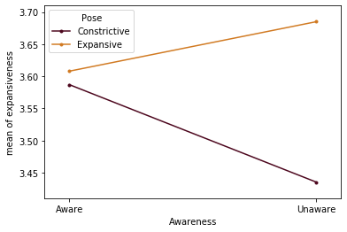

```python
model = ols('expansiveness ~ C(Awareness) + C(Pose) + C(Awareness)*C(Pose)', data=dfANOVA).fit()
table = sm.stats.anova_lm(model, typ=2)
print(table)

fig = interaction_plot(x=dfANOVA['Awareness'], trace=dfANOVA['Pose'], response=dfANOVA['expansiveness'],
    colors=['#4c061d','#d17a22'])
plt.show()
```

#### Discussion interaction effect under "expansiveness"

儘管依照expansiveness變項平均數所繪製的兩因子圖中，似乎有交互作用的存在（兩線可能有交會），但在ANOVA檢定中，p-value(=0.445)>0.05，接受虛無假設（H0）。而可知兩因子在expansiveness此變項中並無顯著的交互作用。亦即，不論哪種覺察狀態（Awareness）下，姿態（Pose）的改變，並不影響受試者認為此姿態確實為強勢（High power）或弱勢（Low power）。

由於並無顯著的交互作用存在，因此近一步分析是否有主效果（main effet）存在。

覺察狀態（Awareness）是否影響對於姿態的看法（expansiveness）？

H0:覺察狀態不會影響對於姿態的看法。

H1:覺察狀態會影響對於姿態的看法。

姿態狀態（Pose）是否影響對於姿態的看法（expansiveness）？

H0:姿態狀態不會影響對於姿態的看法。

H1:姿態狀態會影響對於姿態的看法。

```python
model = ols('expansiveness ~ C(Awareness) + C(Pose)', data=dfANOVA).fit()
table.main = sm.stats.anova_lm(model, typ=2)
print(table.main)
```

```
                  sum_sq     df         F    PR(>F)
C(Awareness)    0.080182    1.0  0.074450  0.785260
C(Pose)         0.999186    1.0  0.927748  0.336667
Residual      205.707211  191.0       NaN       NaN
```

#### Discussion main effect under "expansivenss"

由此主效果的分析可知，覺察狀態的p-value(=0.785)>0.05，接受虛無假設，亦即無論覺察到姿態的強勢與否，皆不會影響對於姿態的看法。此外，姿態狀態的p-value(=0.337)>0.05，接受虛無假設，亦即無論是強勢或弱勢的姿態狀態，皆不會影響對於姿態的看法。